# R Notebook

# Two sample tests with independent samples

```r
library(tidyverse)
library(janitor)
library(infer)

nice <- read_csv("data/nice.csv")
algarve <- read_csv("data/algarve.csv")
```

# Bind and tidy data

```r
apart_prices <- bind_rows(nice,algarve, .id = "location") %>%
                mutate(location = ifelse(location == "1", "nice", "algarve")) %>%
                select(-X1)
head(apart_prices)
```

| location | price |
| --- | --- |
| nice | 1594 |
| nice | 1537 |
| nice | 1565 |
| nice | 1477 |
| nice | 2072 |
| nice | 1608 |

# Visualise

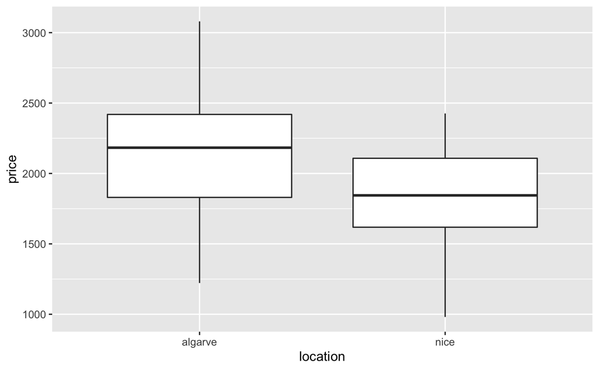

```r
apart_prices %>%
  ggplot() +
  aes(x = location, y= price) +
  geom_boxplot()
```

# Generate the null distribution

What would it look like if there was no difference in prices between each location. If we shuffle the prices and labels for both our samples.

```r
null_distribution <- apart_prices %>%
  specify(response = price, explanatory = location) %>%
  hypothesise(null = "independence") %>%
  # permute type generates permutations of our price and location labels
  generate(reps = 1000, type = "permute") %>%
  calculate(stat = "diff in means", order = c("algarve", "nice"))

head(null_distribution)
```

| replicate | stat |
| --- | --- |
| 1 | 86.19167 |
| 2 | -60.26667 |
| 3 | 48.40000 |
| 4 | -46.22500 |
| 5 | -75.80833 |
| 6 | -70.55833 |

# Calculate observed statistic

```r
observed_stat <- apart_prices %>%
  specify(price ~ location) %>%
  calculate(stat = "diff in means", order = c("algarve", "nice"))

observed_stat
```

| stat |
| --- |
| 251.4 |

# Visualise null distribution and observed stat

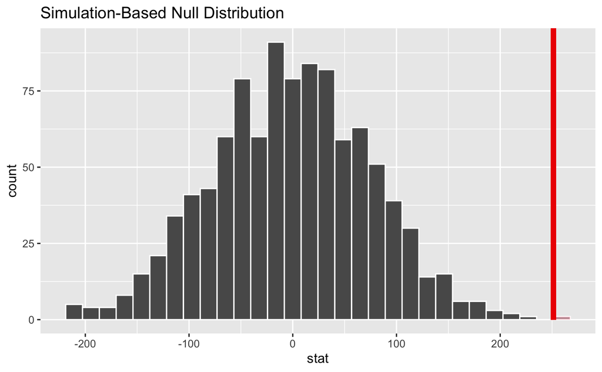

```r
null_distribution %>%
  visualise(bins = 30) +
  shade_p_value(obs_stat = observed_stat, direction = "greater")
```

# Calculate p value

The probability of getting our observed value if there is no difference between prices depending on location

```r
get_p_value(null_distribution, obs_stat = observed_stat, direction = "greater")
```

| p_value |
| --- |
| 0.001 |

There is a 0.1% chance of getting our observed statistic if the null hypothesis were true. As it is incredibly unlikely to have returned the observed value if the null hypothesis were true, this gives us a reasonable indication that we can safely reject the null hypothesis.

We reject H0 and conclude that we have enough evidence in our data to indicate that the average price for a holiday rental in the Algarve is statistically greater than that in Nice.

# Task

We have two more datasets for similar apartment lets in Corfu and Florence.

Frame and perform an independent two-sample test to answer the following question: ‘On average, is the price of 2-bedroom, 14-day holiday apartment lets in Florence significantly lower than that of comparable lets in Corfu?’ Choose α and frame your hypotheses before you see the data You will need to format your data in a combined, tidy dataset prior to performing the test

alpha = 0.5, H0: mean_price_corfu - mean_price_florence = 0 Ha: mean_price_corfu - mean_price_florence > 0

```r
corfu <- read_csv("data/corfu.csv")
florence <- read_csv("data/florence.csv")
apart_prices <- corfu %>%
  bind_rows(florence, .id = "location") %>%
  mutate(location = if_else(location == 1, "corfu", "florence"))
```

# Calculate observed_stat

[output not shown]

# Null distribution

```r
null_distribution <- apart_prices %>%
  specify(response = price, explanatory = location) %>%
  hypothesise(null = "independence") %>%
  generate(reps = 5000, type = "permute") %>%
  calculate(stat = "diff in means", c("corfu", "florence"))
```

# Visualise null distribution and observed stat

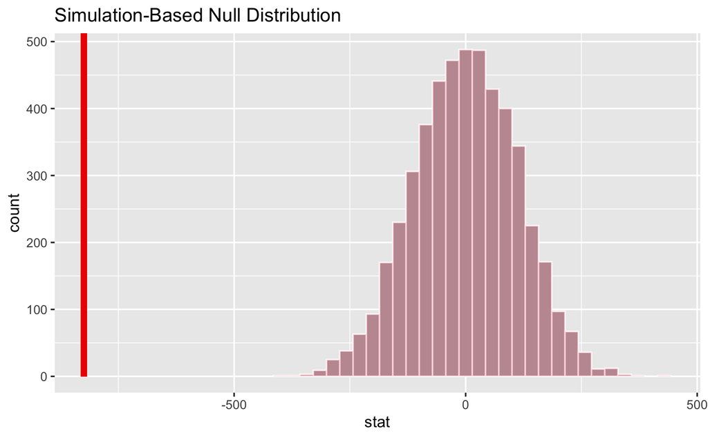

```r
null_distribution %>%
  visualise(bins = 30) +
  shade_p_value(obs_stat = observed_stat, direction = "greater")
```

# Calculate p

```r
get_p_value(x = null_distribution, obs_stat = observed_stat, direction = "greater")
```

| p_value |
| --- |
| 1 |

We conclude that this evidence does not allow us to reject the null hypothesis. There is no significant evidence which allows to conclude that Florence is significantly lower priced than Corfu.

# Test for difference in paired Samples

```r
books <- read_csv("data/ucla_textbooks_f18.csv")
```

Is there a significant difference on average between the prices for new texts offered by the campus bookstore vs the prices of the same texts on Amazon

```r
books %>%
  select(bookstore_new, amazon_new)
```

| bookstore_new | amazon_new |
| --- | --- |
| 47.97 | 47.45 |
| 14.26 | 13.55 |
| NA | NA |
| 13.50 | 12.53 |
| 49.26 | 54.95 |
| 119.97 | 124.80 |
| NA | NA |
| 188.10 | NA |
| 215.75 | NA |
| NA | NA |

[output cut: 191 more lines]